# Assignment 6: Database Set-up in RMarkdown

Kate Sinnott

3/1/2021

# RSQLite Package

The R package DBI (database interface) allows R to interface with SQLite. So first, we install DBI:

```r
library(DBI)
```

# Establishing a database connection

I have already created a database for my SAV restoration project in SQLite, so now I need to connect to that database using `dbConnect`.

```r
restoration_db <- dbConnect(RSQLite::SQLite(),"/Users/katesinnott/Desktop/WILD_6900/SAV_restoration/SAV_restoration.db")
```

# Building database tables

Now I need to start creating my database tables. To do this I use `dbExecute`, then just type in the query like I would in SQLite. This is the database structure I will be building:

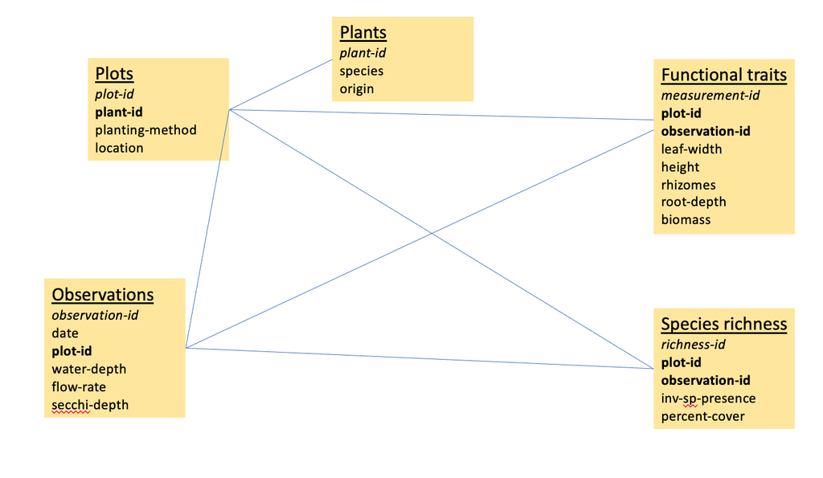

Database diagram

## Table 1: Plants

I started with this table because it doesn’t reference foreign keys from other tables. This table includes information I will need to reference specific plant populations - specifically, the species and the collection locations.

```r
dbExecute(restoration_db, "CREATE TABLE plants (
          plant_id varchar(5) NOT NULL PRIMARY KEY,
          planting_method char(9),
          species varchar(6),
          origin varchar(4)
          );")
```

## Table 2: Plots

This table includes static information about different plots where the plants will be introduced. The foreign key is the plant_id, which references the Plants table. Other attributes are the planting method used and the location of the plots.

```r
dbExecute(restoration_db, "CREATE TABLE plots (
          plot_id varchar(5) NOT NULL PRIMARY KEY,
          planting_method char(9),
          location varchar(6),
          FOREIGN KEY (plant_id) REFERENCES plants(plant_id)
          );")
```

## Table 3: Observations

The observations table includes the data collected at each plot on different collecting days. The foreign key is the plot_id column, which references the Plots table. This data is not static. In addition to date, attributes included are water depth, flow rate, and Secchi depth, which very variable in the restoration system.

```r
dbExecute(restoration_db, "CREATE TABLE observations (
          observation_id varchar(10) NOT NULL PRIMARY KEY,
          date text,
          plot_id varchar(5),
          water_depth float,
          flow_rate float,
          secchi_depth float,
          FOREIGN KEY (plot_id) REFERENCES plots(plot_id)
          );")
```

## Table 4: Functional Traits

This is where measurements of specific plants are recorded. This will be used to determine the success of the different plots. There are two foreign keys: plot_id and observation_id. Functional traits measured are leaf wisth, height, rhizomes, root depth, and shoot biomass.

```r
dbExecute(restoration_db, "CREATE TABLE functional_traits (
          measurement_id varchar(5) NOT NULL PRIMARY KEY,
          plant_id varchar(5),
          observation_id varchar(10),
          leaf_width float,
          height float,
          rhizomes float,
          root_depth float,
          biomass float,
          FOREIGN KEY (plot_id) REFERENCES plots(plot_id),
          FOREIGN KEY (observation_id) REFERENCES observations(observation_id)
          );")
```

## Table 5: Species richness

This table includes measurements to evaluate species richness. It has two foreign keys: observation and plot identifications. Attributes measured are presence of invasive species and percent cover of each species. **Question: do I also need to include plant_id as a foreign key to identify the species for the percent cover? Or is connecting it to plot_id enough?**

```r
dbExecute(restoration_db, "CREATE TABLE species_richness (
          richness_id varchar(10) NOT NULL PRIMARY KEY,
          plot_id varchar(5),
          observation_id varchar(10),
          inv_sp_presence_score integer,
          percent_cover integer,
          FOREIGN KEY (plot_id) REFERENCES plots(plot_id),
          FOREIGN KEY (observation_id) REFERENCES observations(observation_id)
          );")
```